# Exploratory Data Analysis

## Introduction

> This data consists of 426,880 records of used cars for sale on Craigslist. The data was downloaded from Kaggle and can be found at https://www.kaggle.com/datasets/austinreese/craigslist-carstrucks-data.

## Preliminary Data Wrangling

```python
# import necessary libraries
import pandas as pd
import numpy as np
import matplotlib.pyplot as plt
import seaborn as sns
from datetime import datetime
import geopandas as gpd

%matplotlib inline
```

### Load the data and query its structure

```python
# load data and look at first 5 rows
cars_df = pd.read_csv('vehicles.csv', index_col = False)
cars_df.head()
```

|  | id | url | region | region_url | price | year | manufacturer | model | condition | cylinders | ... | size | type | paint_color | image_url | description | county | state | lat | long | posting_date |
| --- | --- | --- | --- | --- | --- | --- | --- | --- | --- | --- | --- | --- | --- | --- | --- | --- | --- | --- | --- | --- | --- |
| 0 | 7222695916 | https://prescott.craigslist.org/cto/d/prescott... | prescott | https://prescott.craigslist.org | 6000 | NaN | NaN | NaN | NaN | NaN | ... | NaN | NaN | NaN | NaN | NaN | NaN | az | NaN | NaN | NaN |
| 1 | 7218891961 | https://fayar.craigslist.org/ctd/d/bentonville... | fayetteville | https://fayar.craigslist.org | 11900 | NaN | NaN | NaN | NaN | NaN | ... | NaN | NaN | NaN | NaN | NaN | NaN | ar | NaN | NaN | NaN |
| 2 | 7221797935 | https://keys.craigslist.org/cto/d/summerland-k... | florida keys | https://keys.craigslist.org | 21000 | NaN | NaN | NaN | NaN | NaN | ... | NaN | NaN | NaN | NaN | NaN | NaN | fl | NaN | NaN | NaN |
| 3 | 7222270760 | https://worcester.craigslist.org/cto/d/west-br... | worcester / central MA | https://worcester.craigslist.org | 1500 | NaN | NaN | NaN | NaN | NaN | ... | NaN | NaN | NaN | NaN | NaN | NaN | ma | NaN | NaN | NaN |
| 4 | 7210384030 | https://greensboro.craigslist.org/cto/d/trinit... | greensboro | https://greensboro.craigslist.org | 4900 | NaN | NaN | NaN | NaN | NaN | ... | NaN | NaN | NaN | NaN | NaN | NaN | nc | NaN | NaN | NaN |

5 rows × 26 columns

```python
# shape of dataset
print('rows: ', cars_df.shape[0])
print('columns: ', cars_df.shape[1])
```

```
rows:  426880
columns:  26
```

```python
# feature (column) details
cars_df.info()
```

```
<class 'pandas.core.frame.DataFrame'>
RangeIndex: 426880 entries, 0 to 426879
Data columns (total 26 columns):
 #   Column        Non-Null Count   Dtype
---  ------        --------------   -----
 0   id            426880 non-null  int64
 1   url           426880 non-null  object
 2   region        426880 non-null  object
 3   region_url    426880 non-null  object
 4   price         426880 non-null  int64
 5   year          425675 non-null  float64
 6   manufacturer  409234 non-null  object
 7   model         421603 non-null  object
 8   condition     252776 non-null  object
 9   cylinders     249202 non-null  object
```

[output cut: 18 more lines]

```python
# percentage of null values by column
null = cars_df.isna().sum() / cars_df.shape[0]
null[null > 0].sort_values()
```

```
posting_date    0.000159
image_url       0.000159
description     0.000164
year            0.002823
transmission    0.005988
fuel            0.007058
odometer        0.010307
model           0.012362
long            0.015342
lat             0.015342
title_status    0.019308
manufacturer    0.041337
type            0.217527
paint_color     0.305011
drive           0.305863
VIN             0.377254
condition       0.407852
cylinders       0.416225
size            0.717675
county          1.000000
dtype: float64
```

```python
# any duplicate rows
cars_df.duplicated().sum()
```

```
0
```

> No duplicate rows

```python
# check for rows with all missing values
cars_df.isna().all(axis=1).sum()
```

```
0
```

> No rows with all missing values

```python
# descriptive stats for numeric vars
cars_df.describe()
```

|  | id | price | year | odometer | county | lat | long |
| --- | --- | --- | --- | --- | --- | --- | --- |
| count | 4.268800e+05 | 4.268800e+05 | 425675.000000 | 4.224800e+05 | 0.0 | 420331.000000 | 420331.000000 |
| mean | 7.311487e+09 | 7.519903e+04 | 2011.235191 | 9.804333e+04 | NaN | 38.493940 | -94.748599 |
| std | 4.473170e+06 | 1.218228e+07 | 9.452120 | 2.138815e+05 | NaN | 5.841533 | 18.365462 |
| min | 7.207408e+09 | 0.000000e+00 | 1900.000000 | 0.000000e+00 | NaN | -84.122245 | -159.827728 |
| 25% | 7.308143e+09 | 5.900000e+03 | 2008.000000 | 3.770400e+04 | NaN | 34.601900 | -111.939847 |
| 50% | 7.312621e+09 | 1.395000e+04 | 2013.000000 | 8.554800e+04 | NaN | 39.150100 | -88.432600 |
| 75% | 7.315254e+09 | 2.648575e+04 | 2017.000000 | 1.335425e+05 | NaN | 42.398900 | -80.832039 |
| max | 7.317101e+09 | 3.736929e+09 | 2022.000000 | 1.000000e+07 | NaN | 82.390818 | 173.885502 |

### Investigate some of the variables

```python
# cylinders is an object field, which seems a bit strange. lets check it.
cars_df.cylinders.sample(10)
```

```
176278            NaN
143446    4 cylinders
295496            NaN
319308            NaN
154153    8 cylinders
321494            NaN
119962    8 cylinders
382893    6 cylinders
14365     8 cylinders
60910     4 cylinders
Name: cylinders, dtype: object
```

> OK, I see the cyclinders is an object data type because each non-missing entry includes the word **cylinder**.

```python
# size is missing in over 70% of rows. lets look at size column.
cars_df['size'].unique()
```

```
array([nan, 'full-size', 'mid-size', 'compact', 'sub-compact'],
      dtype=object)
```

```python
# check transmission values
cars_df.transmission.value_counts()
```

```
automatic    336524
other         62682
manual        25118
Name: transmission, dtype: int64
```

```python
# check type values
cars_df.type.value_counts().sort_index()
```

```
SUV            77284
bus              517
convertible     7731
coupe          19204
hatchback      16598
mini-van        4825
offroad          609
other          22110
pickup         43510
sedan          87056
truck          35279
van             8548
wagon          10751
Name: type, dtype: int64
```

```python
# check manufacturer values
cars_df.manufacturer.value_counts().nlargest(15)
```

```
ford             70985
chevrolet        55064
toyota           34202
honda            21269
nissan           19067
jeep             19014
ram              18342
gmc              16785
bmw              14699
dodge            13707
mercedes-benz    11817
hyundai          10338
subaru            9495
volkswagen        9345
kia               8457
Name: manufacturer, dtype: int64
```

## Notes on data

### Data types

- we won't do math operations on id column. can change to object.
- we won't do math on lat / long columns; however, will use later for map so will leave data type as is.

### Data issues

- county column has no values and can be dropped.
- size column has over 70 percent missing values and can be removed.
- cylinder column has the word "cylinder" for each non-missing entry. this is not an issue per se, however column has over 40% missing values.
- url columns are not necessary and can be removed.
- VIN column is not needed and can be removed.
- description column is not needed and can be removed.
- posting_data column is not needed and can be removed.
- price has a minimum of 0 and maximum of 3.7 billion. that seems a bit expensive for a car.

## Clean

- drop the following columns
  - url, region_url, image_url, VIN, description, county, size, posting_date
- change data types
  - id from int to object
  - year from float to int
- subset data to vehicle prices 100K and below
- handle missing data
- create vehicle_age column

```python
# first, lets make a copy of the dataframe
cars_df_clean = cars_df.copy()
cars_df_clean.head(2)
```

|  | id | url | region | region_url | price | year | manufacturer | model | condition | cylinders | ... | size | type | paint_color | image_url | description | county | state | lat | long | posting_date |
| --- | --- | --- | --- | --- | --- | --- | --- | --- | --- | --- | --- | --- | --- | --- | --- | --- | --- | --- | --- | --- | --- |
| 0 | 7222695916 | https://prescott.craigslist.org/cto/d/prescott... | prescott | https://prescott.craigslist.org | 6000 | NaN | NaN | NaN | NaN | NaN | ... | NaN | NaN | NaN | NaN | NaN | NaN | az | NaN | NaN | NaN |
| 1 | 7218891961 | https://fayar.craigslist.org/ctd/d/bentonville... | fayetteville | https://fayar.craigslist.org | 11900 | NaN | NaN | NaN | NaN | NaN | ... | NaN | NaN | NaN | NaN | NaN | NaN | ar | NaN | NaN | NaN |

2 rows × 26 columns

### Drop unneccessary columns

```python
# drop url, region_url, image_url, description, county, size, and posting_date columns
rem_cols = ['url', 'region_url', 'image_url', 'VIN',
            'description', 'county', 'size', 'posting_date']
cars_df_clean.drop(rem_cols, axis = 1, inplace = True)
```

```python
# check columns have been removed
cars_df_clean.info()
```

```
<class 'pandas.core.frame.DataFrame'>
RangeIndex: 426880 entries, 0 to 426879
Data columns (total 18 columns):
 #   Column        Non-Null Count   Dtype
---  ------        --------------   -----
 0   id            426880 non-null  int64
 1   region        426880 non-null  object
 2   price         426880 non-null  int64
 3   year          425675 non-null  float64
 4   manufacturer  409234 non-null  object
 5   model         421603 non-null  object
 6   condition     252776 non-null  object
 7   cylinders     249202 non-null  object
 8   fuel          423867 non-null  object
 9   odometer      422480 non-null  float64
 10  title_status  418638 non-null  object
 11  transmission  424324 non-null  object
 12  drive         296313 non-null  object
 13  type          334022 non-null  object
 14  paint_color   296677 non-null  object
 15  state         426880 non-null  object
 16  lat           420331 non-null  float64
 17  long          420331 non-null  float64
dtypes: float64(4), int64(2), object(12)
memory usage: 58.6+ MB
```

```python
def change_dtype(df, cols, type):
    '''
    change_dtype: change data type of columns
    input: dataframe, list of columns, data type
    output: dataframe with changed column data types
    '''
    for col in cols:
        df[col] = df[col].astype(type)
    return(df)
```

### Change data types

```python
# change columns to object data type
str_cols = ['id'] # columns to change to object

change_dtype(cars_df_clean, str_cols, str) # call for id column

# check result
cars_df_clean.info()
```

```
<class 'pandas.core.frame.DataFrame'>
RangeIndex: 426880 entries, 0 to 426879
Data columns (total 18 columns):
 #   Column        Non-Null Count   Dtype
---  ------        --------------   -----
 0   id            426880 non-null  object
 1   region        426880 non-null  object
 2   price         426880 non-null  int64
 3   year          425675 non-null  float64
 4   manufacturer  409234 non-null  object
 5   model         421603 non-null  object
 6   condition     252776 non-null  object
 7   cylinders     249202 non-null  object
 8   fuel          423867 non-null  object
 9   odometer      422480 non-null  float64
 10  title_status  418638 non-null  object
 11  transmission  424324 non-null  object
 12  drive         296313 non-null  object
 13  type          334022 non-null  object
 14  paint_color   296677 non-null  object
 15  state         426880 non-null  object
 16  lat           420331 non-null  float64
 17  long          420331 non-null  float64
dtypes: float64(4), int64(1), object(13)
memory usage: 58.6+ MB
```

### Get a subset of vehicle prices

```python
# subset price to items with price between 1000 and 100,000
cars_df_clean = cars_df_clean[cars_df_clean['price'].between(1000.00, 100000.00)]
```

```python
# check result
cars_df_clean.info()
```

```
<class 'pandas.core.frame.DataFrame'>
Int64Index: 379910 entries, 0 to 426879
Data columns (total 18 columns):
 #   Column        Non-Null Count   Dtype
---  ------        --------------   -----
 0   id            379910 non-null  object
 1   region        379910 non-null  object
 2   price         379910 non-null  int64
 3   year          378746 non-null  float64
 4   manufacturer  364940 non-null  object
 5   model         375506 non-null  object
 6   condition     236829 non-null  object
 7   cylinders     224846 non-null  object
 8   fuel          377319 non-null  object
 9   odometer      377838 non-null  float64
 10  title_status  373352 non-null  object
 11  transmission  378100 non-null  object
 12  drive         264897 non-null  object
 13  type          298837 non-null  object
 14  paint_color   271322 non-null  object
 15  state         379910 non-null  object
 16  lat           376462 non-null  float64
 17  long          376462 non-null  float64
dtypes: float64(4), int64(1), object(13)
memory usage: 55.1+ MB
```

### Check for null values again, following initial cleaning steps

```python
# lets check the missing value percentages again following some cleaning
null = cars_df_clean.isna().sum() / cars_df_clean.shape[0]
null[null > 0].sort_values()
```

```
year            0.003064
transmission    0.004764
odometer        0.005454
fuel            0.006820
lat             0.009076
long            0.009076
model           0.011592
title_status    0.017262
manufacturer    0.039404
type            0.213401
paint_color     0.285826
drive           0.302737
condition       0.376618
cylinders       0.408160
dtype: float64
```

### cylinders column still contains over 40% missing values. Delete column.

```python
# after other cleaning, remove columns with more the 40% missing values
cars_df_clean.drop(['cylinders'], axis = 1, inplace = True)
```

```python
cars_df_clean.info()
```

```
<class 'pandas.core.frame.DataFrame'>
Int64Index: 379910 entries, 0 to 426879
Data columns (total 17 columns):
 #   Column        Non-Null Count   Dtype
---  ------        --------------   -----
 0   id            379910 non-null  object
 1   region        379910 non-null  object
 2   price         379910 non-null  int64
 3   year          378746 non-null  float64
 4   manufacturer  364940 non-null  object
 5   model         375506 non-null  object
 6   condition     236829 non-null  object
 7   fuel          377319 non-null  object
 8   odometer      377838 non-null  float64
 9   title_status  373352 non-null  object
 10  transmission  378100 non-null  object
 11  drive         264897 non-null  object
 12  type          298837 non-null  object
 13  paint_color   271322 non-null  object
 14  state         379910 non-null  object
 15  lat           376462 non-null  float64
 16  long          376462 non-null  float64
dtypes: float64(4), int64(1), object(12)
memory usage: 52.2+ MB
```

### Drop rows with missing values

```python
# finally, drop rows with missing values
cars_df_clean = cars_df_clean.dropna(axis=0)

# check shape of clean dataframe
print('rows: ', cars_df_clean.shape[0])
print('columns: ', cars_df_clean.shape[1])
```

```
rows:  133870
columns:  17
```

```python
# check info
cars_df_clean.info()
```

```
<class 'pandas.core.frame.DataFrame'>
Int64Index: 133870 entries, 31 to 426878
Data columns (total 17 columns):
 #   Column        Non-Null Count   Dtype
---  ------        --------------   -----
 0   id            133870 non-null  object
 1   region        133870 non-null  object
 2   price         133870 non-null  int64
 3   year          133870 non-null  float64
 4   manufacturer  133870 non-null  object
 5   model         133870 non-null  object
 6   condition     133870 non-null  object
 7   fuel          133870 non-null  object
 8   odometer      133870 non-null  float64
 9   title_status  133870 non-null  object
 10  transmission  133870 non-null  object
 11  drive         133870 non-null  object
 12  type          133870 non-null  object
 13  paint_color   133870 non-null  object
 14  state         133870 non-null  object
 15  lat           133870 non-null  float64
 16  long          133870 non-null  float64
dtypes: float64(4), int64(1), object(12)
memory usage: 18.4+ MB
```

### Create vehicle age column

```python
# first, we'll change data type of year from float to int
int_cols = ['year']

change_dtype(cars_df_clean, int_cols, int) # change year from float to int now that there are no more missing values

# create vehicle age based on subtracting year from current year
current_year = datetime.today().year
cars_df_clean['vehicle_age'] = current_year - cars_df_clean['year']
cars_df_clean.vehicle_age.sample(5)
```

```
292722     5
227669    14
413449    16
314639    16
291677     9
Name: vehicle_age, dtype: int64
```

```python
# write out clean data file
cars_df_clean.to_csv('clean_vehicle_data.csv', index = False)
```

### A couple of functions to assist with countplots

```python
# splitJoin function
'''
Sources: (1) https://www.freecodecamp.org/news/python-string-split-and-join-methods-explained-with-examples/
         (2) Udacity review
splitJoin(): split a string, adding a space before an uppercase letter
Input: string
Output: formatted string
'''

def splitJoin(string):
    return ''.join([x if x.islower() else f" {x}" for x in string])
```

```python
# countplot function
'''
subCountPlot: countplot is called numerous times, so best to have a function to handle.
Input: dataframe, x variable, hue variable, color, color palette, and order x variable.
Output: countplot with formatted axes and title
Source: Udacity review

Expanded function to pass either x or y variable for situations where categorical variable fits better on y-axis
'''

def subCountPlot(df, plt_var, hue_var=None, color=0, palette=None, order=None, xy=None):
    plt.figure(figsize=[14, 8]) # plot figure size


    if xy == 'x':
        sns.countplot(data = df, x = plt_var, hue = hue_var, color = sns.color_palette()[color],
                     palette = palette, order = order, edgecolor = 'black')
        plt_var = splitJoin(plt_var).replace('_', ' ') # if there is an underscore, replace with a space
        plt.xlabel(plt_var.title(), weight = 'bold')
        plt.ylabel('Frequency'.title(), weight = 'bold')
    elif xy == 'y':
        sns.countplot(data = df, y = plt_var, hue = hue_var, color = sns.color_palette()[color],
                     palette = palette, order = order, edgecolor = 'black')
        plt_var = splitJoin(plt_var).replace('_', ' ') # if there is an underscore, replace with a space
        plt.xlabel('Frequency'.title(), weight = 'bold')
        plt.ylabel(plt_var.title(), weight = 'bold')

    if hue_var:
        hue_var = splitJoin(hue_var).replace('_', ' ') # same for hue_var, if one is passed in.

    # add titles and axis labels
    plt.title(f'''Distribution of {plt_var} {'by' if hue_var else ''} {hue_var if hue_var else ''}'''.title(), weight = 'bold')
```

## Univariate exploration

### Correlation matrix for numeric variables

- are there strong positive or negative correlations among numeric variables?

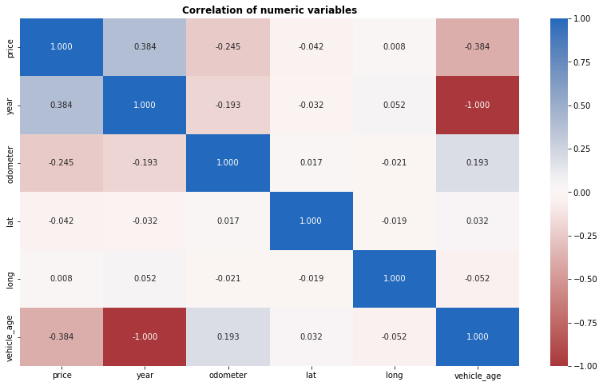

```python
# numeric variables correlation plot
plt.figure(figsize = [14, 8])
sns.heatmap(cars_df_clean.corr(), annot = True, fmt = '.3f',
           cmap = 'vlag_r', center = 0)
plt.title('Correlation of numeric variables', weight = 'bold')
plt.show()
```

> There is a postive correlation between
> - **year and price** - as year increases, price increase
> - **vehicle age and odometer** - as vehicle age increases, odometer reading increases

> There is negative correlations between
> - **year and odometer** - as year increases, odomoter reading decreases
> - **price and odometer** - as price decreases, odometer reading increase

#### What are the percentage of vehicles are by drive type?

```python
# look at drive train values
drive_vals = cars_df_clean.drive.value_counts() / cars_df_clean.shape[0]
drive_vals
```

```
4wd    0.389400
fwd    0.377247
rwd    0.233353
Name: drive, dtype: float64
```

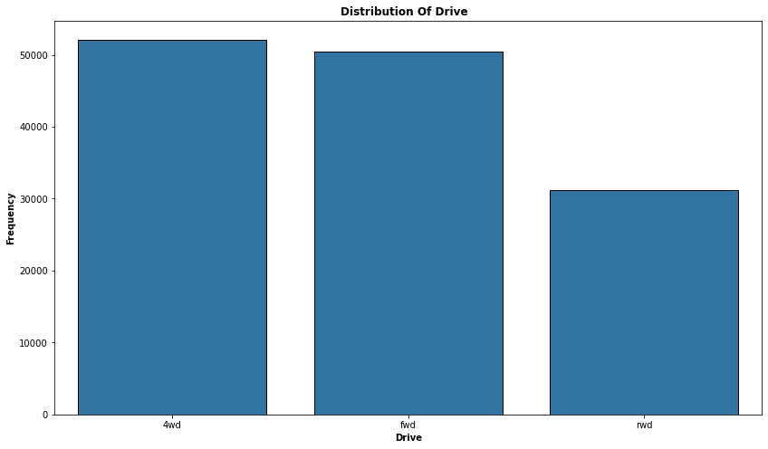

```python
# frequency of drive train values
subCountPlot(cars_df_clean, plt_var = 'drive', order = drive_vals.index, xy = 'x');
```

> Four-wheel drive are approximately 39% of total \ Front-wheel drive are approximately 38% of total \ Rear-wheel drive are approximately 23% of total

#### What are the most popular vehicle paint colors?

```python
# look at color values
color_vals = cars_df_clean.paint_color.value_counts().sort_index()
color_vals / cars_df_clean.shape[0]
```

```
black     0.204489
blue      0.112385
brown     0.026772
custom    0.018563
green     0.028714
grey      0.096198
orange    0.006252
purple    0.002667
red       0.111601
silver    0.143512
white     0.241376
yellow    0.007470
Name: paint_color, dtype: float64
```

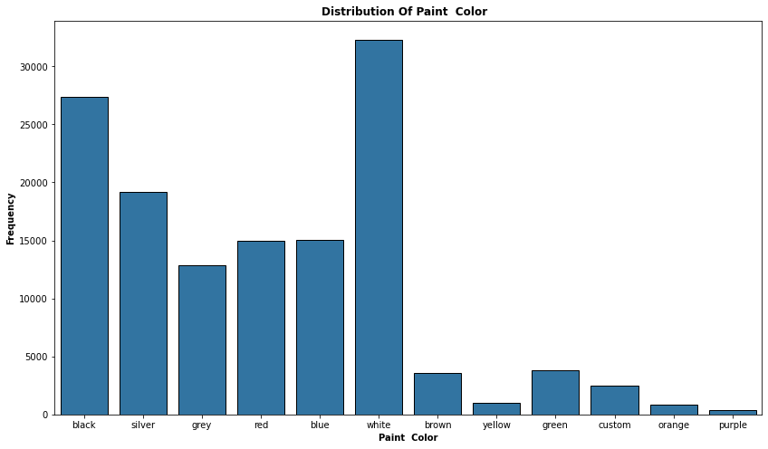

```python
# frequency of color values
subCountPlot(cars_df_clean, plt_var = 'paint_color', xy = 'x');
```

> White and black color vehicles make up approximately 45% of the total.

#### Which vehicle manufacturers occur most frequently among the top 15 most frequent?

```python
# look at vehicle manufacturers
manuf_vals = cars_df_clean.manufacturer.value_counts().sort_index().nlargest(15)
manuf_vals / cars_df_clean.shape[0]
```

```
ford             0.167693
chevrolet        0.140547
toyota           0.084463
honda            0.057690
nissan           0.051027
jeep             0.045537
gmc              0.037589
bmw              0.035460
dodge            0.032883
ram              0.031725
volkswagen       0.029768
hyundai          0.027258
mercedes-benz    0.025308
subaru           0.022104
kia              0.020976
Name: manufacturer, dtype: float64
```

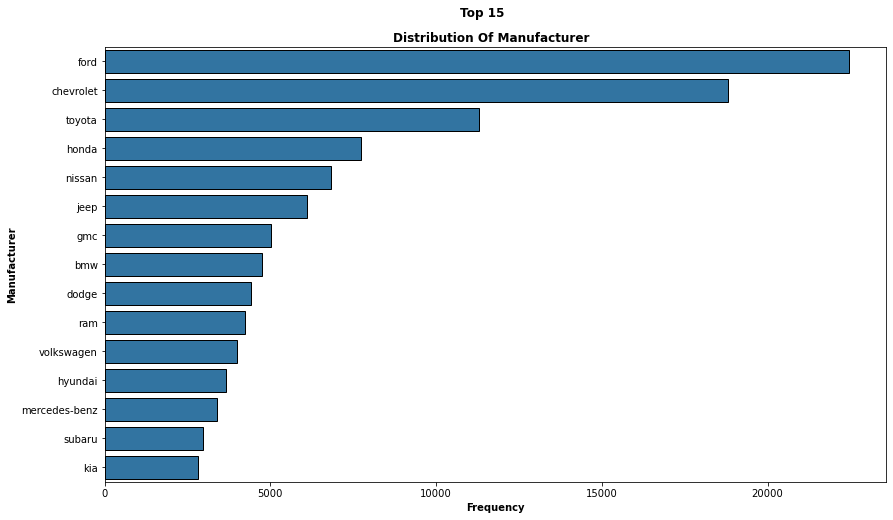

```python
# frequency of vehicle manufacturer values
subCountPlot(cars_df_clean, plt_var = 'manufacturer', order = manuf_vals.index, xy = 'y')
plt.suptitle('Top 15', y = .95, weight = 'bold');
```

> For the 15 most frequently sold manufacturers, Ford and Chevy lead the way with 30% of the total.

#### Which vehicle models occur most frequently among the top 15 most frequent?

```python
# look at vehicle model
model_vals = cars_df_clean.model.value_counts().nlargest(15)
model_vals / cars_df_clean.shape[0]
```

```
f-150             0.015097
silverado 1500    0.012400
1500              0.007500
camry             0.007022
accord            0.006671
civic             0.006506
tacoma            0.006402
altima            0.005939
wrangler          0.005759
silverado         0.005722
mustang           0.005319
escape            0.005192
2500              0.004885
explorer          0.004766
corvette          0.004579
Name: model, dtype: float64
```

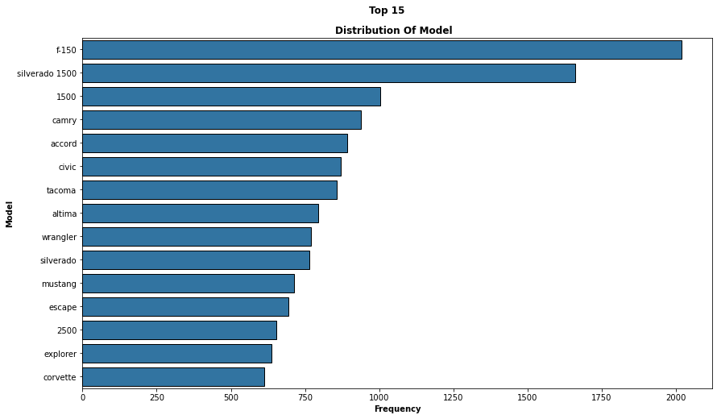

```python
# frequency of vehicle model values
subCountPlot(cars_df_clean, plt_var = 'model', order = model_vals.index, xy = 'y')
plt.suptitle('Top 15', y = .95, weight = 'bold');
```

> Pickup trucks are popular - Ford F-150 and Chevy Silverado 1500 appear most frequently. 1.5% and 1.25% respectively.

#### Which transmission type occurs most frequently?

```python
# look at transmission values
trans_vals = cars_df_clean.transmission.value_counts()
trans_vals / cars_df_clean.shape[0]
```

```
automatic    0.742586
other        0.194637
manual       0.062777
Name: transmission, dtype: float64
```

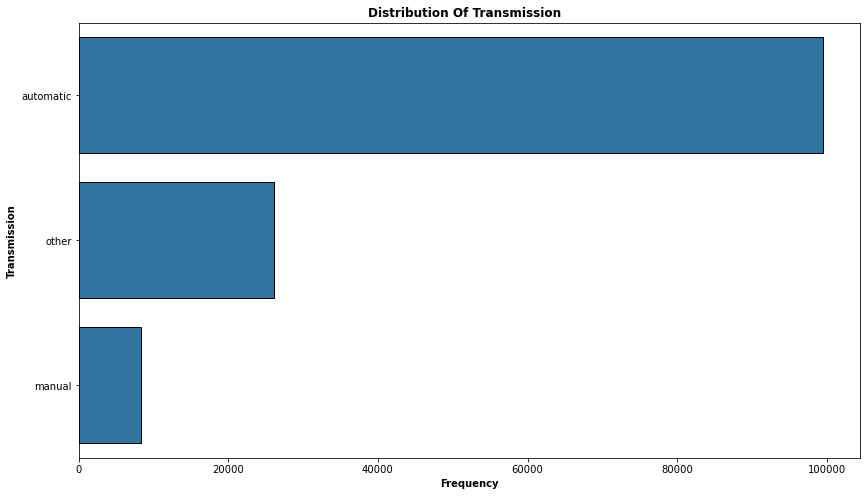

```python
# frequency of transmission values
subCountPlot(cars_df_clean, plt_var = 'transmission', order = trans_vals.index, xy = 'y')
```

> A whopping 75% of vehicles have Automatic transmission.

#### Which vehicle type occurs most frequently?

```python
# look at vehicle type values
type_vals = cars_df_clean.type.value_counts() / cars_df_clean.shape[0]
type_vals
```

```
sedan          0.280123
SUV            0.217995
truck          0.112796
pickup         0.110196
coupe          0.071749
hatchback      0.055248
other          0.040726
wagon          0.030582
convertible    0.029222
van            0.026361
mini-van       0.020393
offroad        0.003526
bus            0.001083
Name: type, dtype: float64
```

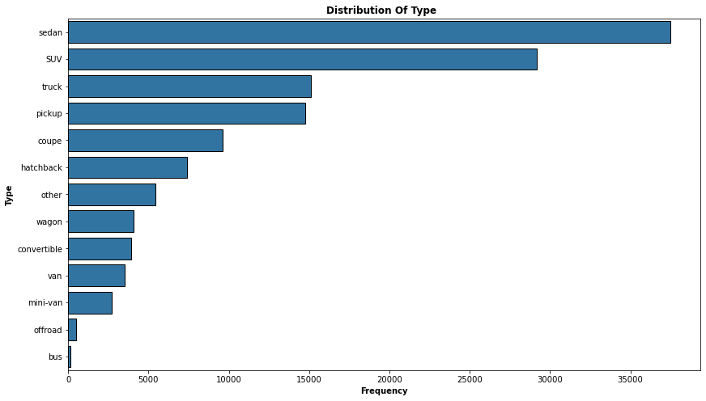

```python
# frequency of vehicle type values
subCountPlot(cars_df_clean, plt_var = 'type', order = type_vals.index, xy = 'y')
```

> Approximately 50% of vehicles are Sedans and SUVs

#### What vehicle conditions occur most frequently?

```python
# look at vehicle condition values
cond_vals = cars_df_clean.condition.value_counts().sort_index()
cond_vals / cars_df_clean.shape[0]
```

```
excellent    0.403735
fair         0.026608
good         0.474811
like new     0.089408
new          0.003735
salvage      0.001703
Name: condition, dtype: float64
```

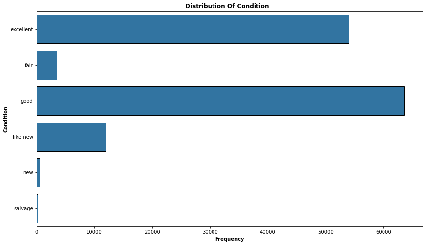

```python
# frequency of vehicle condition values
subCountPlot(cars_df_clean, plt_var = 'condition', order = cond_vals.index, xy = 'y')
```

> Approximately 87% of vehicles are in good (47%) or excellent (40%) condition.

#### How is vehicle age distributed?

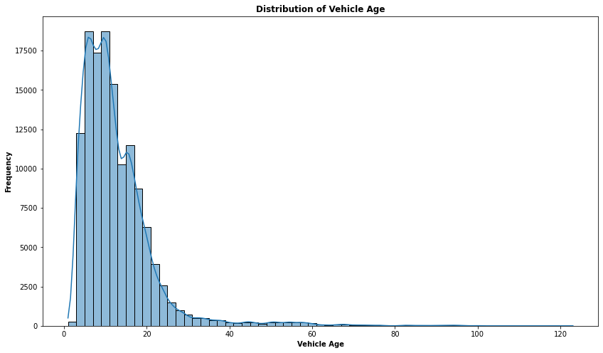

```python
# histogram of vehicle age
plt.figure(figsize=[14, 8])
sns.histplot(data = cars_df_clean, x = 'vehicle_age', binwidth = 2, kde = True)
plt.xlabel('Vehicle Age', weight = 'bold')
plt.ylabel('Frequency', weight = 'bold')
plt.title('Distribution of Vehicle Age', weight = 'bold');
```

> Distribution skewed to the right. The bulk of vehicles are in the 0 to 20 year old range. There is a long tail to the right leading out to the 120 year-old range.

#### What is the distribution of vehicle price?

```python
# mean vehicle price
cars_df_clean.price.mean()
```

```
17300.93053708822
```

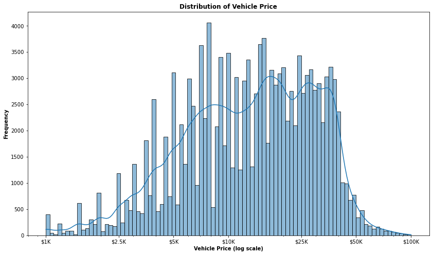

```python
# histogram of vehicle price
plt.figure(figsize=[14, 8])
sns.histplot(data = cars_df_clean, x = 'price', log_scale = True, kde = True)
plt.xticks([1000, 2500, 5000, 10000, 25000, 50000, 100000],
          ['$1K', '$2.5K', '$5K', '$10K', '$25K', '$50K', '$100K'])
plt.xlabel('Vehicle Price (log scale)', weight = 'bold')
plt.ylabel('Frequency', weight = 'bold')
plt.title('Distribution of Vehicle Price', weight = 'bold');
```

> The mean vehicle price is 17,300. This distribution is multi-model is left-skewed.

## Bivariate Analysis

### Numeric v. Categorical variables

```python
# box plots
'''
boxes(x, y, **kwargs): call Seaborn PairGrid to display multiple box plots
Input: dataframe, x variables, y variables, additional arguments
Output: box plots
'''

def boxes (x, y, **kwargs):
    base_color = sns.color_palette()[0]
    sns.boxplot(x = x, y = y, color = base_color)
```

#### How are the numeric variables distributed with respect to categorical variables?

```python
# set up variables for box plots
num_vars = ['price', 'vehicle_age'] # set numeric variables
cat_vars = ['condition', 'type'] # first set categoric variables
cat_vars2 = ['manufacturer'] # second set categoric variables
cat_vars3 = ['transmission', 'drive', 'paint_color'] # third set categoric variables
```

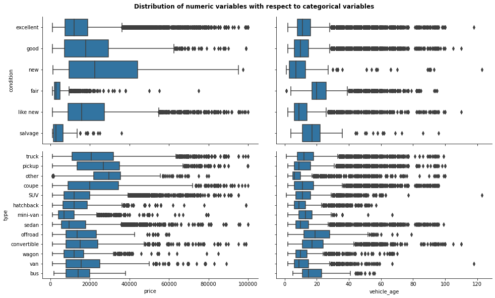

```python
# set up first set
g = sns.PairGrid(data = cars_df_clean, y_vars = cat_vars,
                x_vars = num_vars,
               height = 4)

g.map(boxes) # call function

# plot size and title
g.fig.set_size_inches(14, 8)
plt.suptitle('Distribution of numeric variables with respect to categorical variables', y = 1.02, weight = 'bold')

plt.show();
```

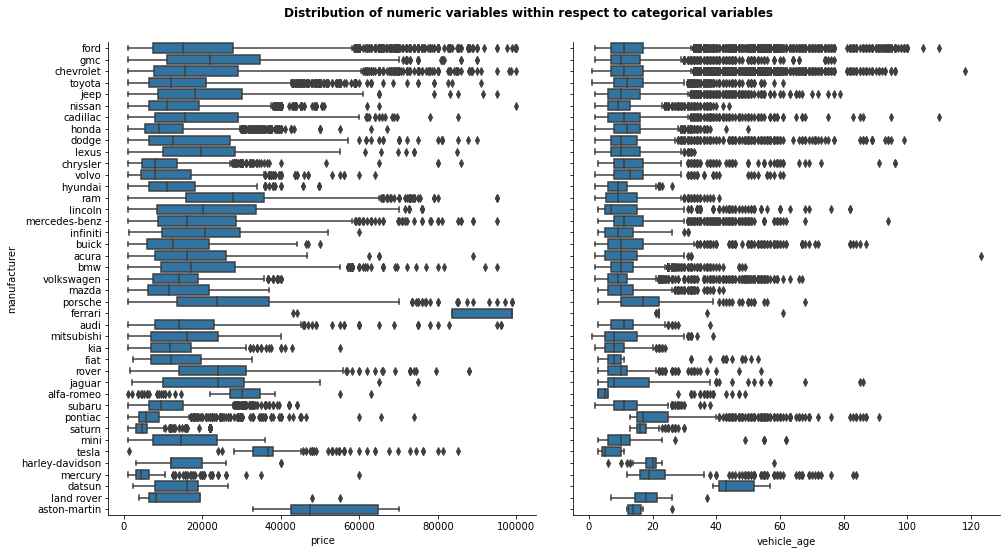

```python
# set up second set
g = sns.PairGrid(data = cars_df_clean, y_vars = cat_vars2,
                x_vars = num_vars, height = 4)

g.map(boxes) # call function

# plot size and title
g.fig.set_size_inches(14, 8)
plt.suptitle('Distribution of numeric variables within respect to categorical variables', y = 1.02, weight = 'bold')

plt.show();
```

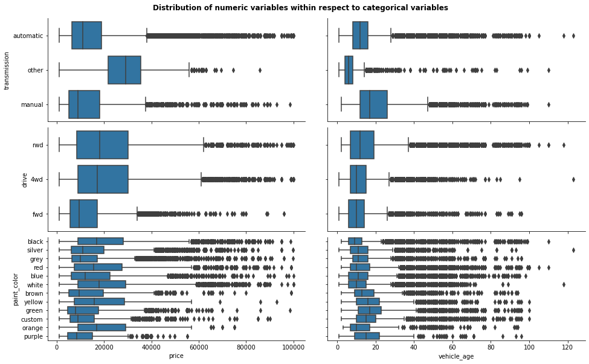

```python
# set up third set
g = sns.PairGrid(data = cars_df_clean, y_vars = cat_vars3,
                x_vars = num_vars, height = 4)

g.map(boxes) # call function

# plot size and title
g.fig.set_size_inches(14, 8)
plt.suptitle('Distribution of numeric variables within respect to categorical variables', y = 1.02, weight = 'bold')

plt.show();
```

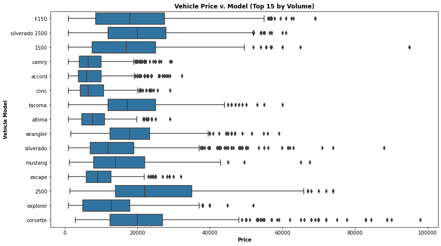

```python
# fourth set - done separately and not using function so the model order can be passed.

plt.figure(figsize=[14, 8])
sns.boxplot(data = cars_df_clean, x = 'price', y = 'model',
            order = model_vals.index, color = sns.color_palette()[0])
plt.xlabel('Price', weight = 'bold')
plt.ylabel('Vehicle Model', weight = 'bold')
plt.title('Vehicle Price v. Model (Top 15 by Volume)', weight = 'bold');
```

> There is consistency in the box plots. They are mostly right-skewed distributions with outliers out beyond 30K in price and 30 years of age. It makes sense to me that the bulk of vehicles would be between 10K and 30K in price and roughly between 5 to 25 years of age.

#### What is the mean vehicle price by state?

```python
# average price by state
mean_price_state = cars_df_clean.groupby(['state']).mean()['price'].reset_index()
mean_price_state
```

|  | state | price |
| --- | --- | --- |
| 0 | ak | 25437.861780 |
| 1 | al | 21233.955526 |
| 2 | ar | 18683.300728 |
| 3 | az | 17737.398264 |
| 4 | ca | 17433.000701 |
| 5 | co | 15877.181236 |
| 6 | ct | 15536.253661 |
| 7 | dc | 15238.830366 |
| 8 | de | 15338.303896 |
| 9 | fl | 17576.732716 |
| 10 | ga | 20184.984489 |
| 11 | hi | 19272.151351 |
| 12 | ia | 15305.024736 |
| 13 | id | 16262.322817 |
| 14 | il | 16776.322399 |
| 15 | in | 17559.212286 |
| 16 | ks | 16512.497639 |
| 17 | ky | 19089.454920 |
| 18 | la | 19554.675939 |
| 19 | ma | 16003.704630 |
| 20 | md | 19058.095851 |
| 21 | me | 14850.162887 |
| 22 | mi | 18296.618973 |
| 23 | mn | 16358.699967 |
| 24 | mo | 19086.840379 |
| 25 | ms | 16677.625683 |
| 26 | mt | 16939.655887 |
| 27 | nc | 18595.866777 |
| 28 | nd | 18506.601810 |
| 29 | ne | 14259.531977 |
| 30 | nh | 14939.276498 |
| 31 | nj | 12984.217553 |
| 32 | nm | 19143.588859 |
| 33 | nv | 16876.627158 |
| 34 | ny | 17884.435484 |
| 35 | oh | 15572.595666 |
| 36 | ok | 18751.007952 |
| 37 | or | 13969.960586 |
| 38 | pa | 15786.051925 |
| 39 | ri | 15240.772549 |
| 40 | sc | 20061.797395 |
| 41 | sd | 18327.950739 |
| 42 | tn | 20891.514840 |
| 43 | tx | 18142.969258 |
| 44 | ut | 19564.352751 |
| 45 | va | 15951.403620 |
| 46 | vt | 16035.182336 |
| 47 | wa | 13265.602273 |
| 48 | wi | 18034.763585 |
| 49 | wv | 23166.113111 |
| 50 | wy | 22748.149780 |

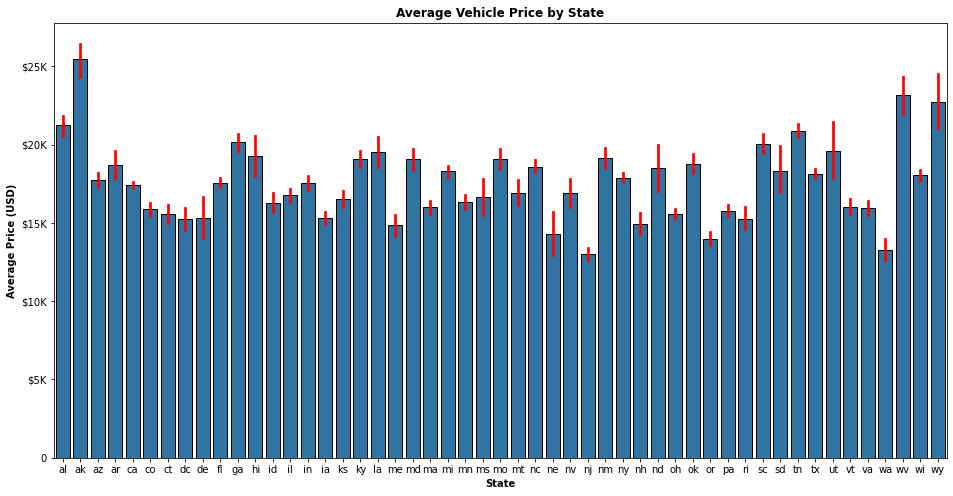

```python
# look at average vehicle price by state
plt.figure(figsize=[16, 8]) # a bit wider so state labels are readable

sns.barplot(data = cars_df_clean, y = 'price', x = 'state', color = sns.color_palette()[0],
           edgecolor = 'black', errcolor = 'Red')
plt.yticks([0, 5000, 10000, 15000, 20000, 25000],
          [0, '$5K', '$10K', '$15K', '$20K', '$25K']) # want dollars on the y-axis
plt.xlabel('State', weight = 'bold')
plt.ylabel('Average Price (USD)', weight = 'bold')
plt.title('Average Vehicle Price by State', weight = 'bold');
```

> The state with the highest average vehicle price is Alaska.

#### What is the average vehicle price by manufacturer?

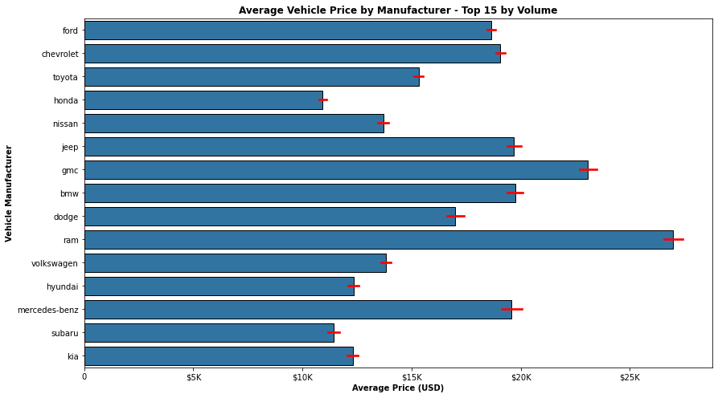

```python
# look at average vehicle price by manufacturer
plt.figure(figsize=[14, 8])
sns.barplot(data = cars_df_clean, x = 'price', y = 'manufacturer', color = sns.color_palette()[0],
           order = manuf_vals.index, edgecolor = 'black', errcolor = 'Red')
plt.xticks([0, 5000, 10000, 15000, 20000, 25000],
          [0, '$5K', '$10K', '$15K', '$20K', '$25K'])
plt.ylabel('Vehicle Manufacturer', weight = 'bold')
plt.xlabel('Average Price (USD)', weight = 'bold')
plt.title('Average Vehicle Price by Manufacturer - Top 15 by Volume', weight = 'bold');
```

> Dodge Ram has the highest average price in this list of top 15 by volume manufacturers.

#### What is the average vehicle price by model?

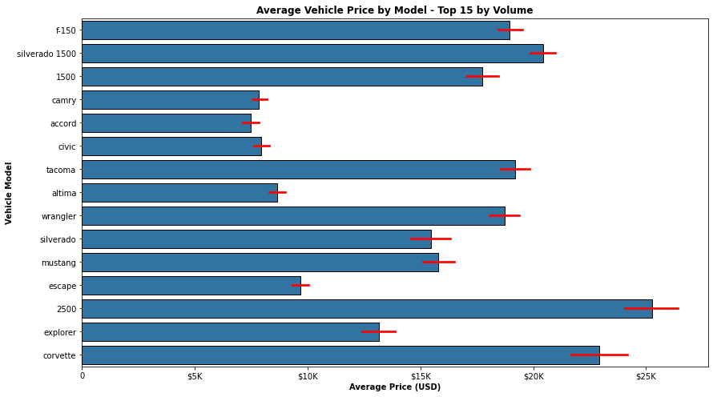

```python
# look at average vehicle price by model
plt.figure(figsize=[14, 8])
sns.barplot(data = cars_df_clean, x = 'price', y = 'model', color = sns.color_palette()[0],
           order = model_vals.index, edgecolor = 'black', errcolor = 'Red')
plt.xticks([0, 5000, 10000, 15000, 20000, 25000],
          [0, '$5K', '$10K', '$15K', '$20K', '$25K'])
plt.ylabel('Vehicle Model', weight = 'bold')
plt.xlabel('Average Price (USD)', weight = 'bold')
plt.title('Average Vehicle Price by Model - Top 15 by Volume', weight = 'bold');
```

> The 2500 truck has the highest average price. Honda accord, the lowest average price.

#### What is the average vehicle price by vehicle type?

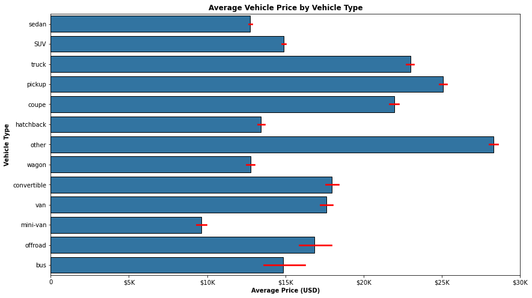

```python
# look at average vehicle price by type
plt.figure(figsize=[14, 8])
sns.barplot(data = cars_df_clean, x = 'price', y = 'type', color = sns.color_palette()[0],
           order = type_vals.index, edgecolor = 'black', errcolor = 'Red')
plt.xticks([0, 5000, 10000, 15000, 20000, 25000, 30000],
          [0, '$5K', '$10K', '$15K', '$20K', '$25K', '$30K'])
plt.ylabel('Vehicle Type', weight = 'bold')
plt.xlabel('Average Price (USD)', weight = 'bold')
plt.title('Average Vehicle Price by Vehicle Type', weight = 'bold');
```

#### What is the average vehicle price by vehicle condition?

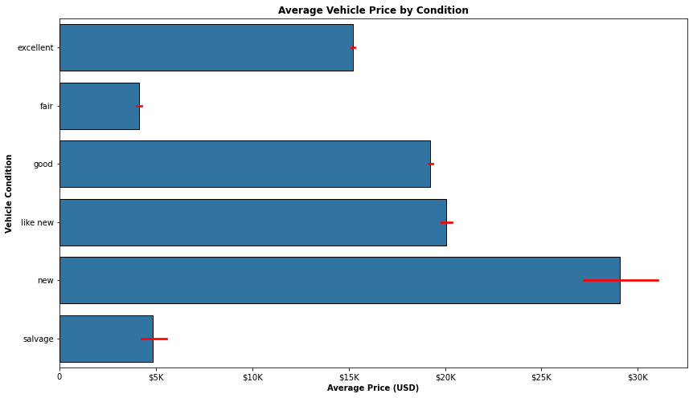

```python
# look at average vehicle price by condition
plt.figure(figsize=[14, 8])
sns.barplot(data = cars_df_clean, x = 'price', y = 'condition', color = sns.color_palette()[0],
           order = cond_vals.index, edgecolor = 'black', errcolor = 'Red')
plt.xticks([0, 5000, 10000, 15000, 20000, 25000, 30000],
          [0, '$5K', '$10K', '$15K', '$20K', '$25K', '$30K'])
plt.ylabel('Vehicle Condition', weight = 'bold')
plt.xlabel('Average Price (USD)', weight = 'bold')
plt.title('Average Vehicle Price by Condition', weight = 'bold');
```

> As one would expect, average price of a new car is highest. A virtual tie for lowest average price between fair and salvage.

#### What is the average vehicle price by color?

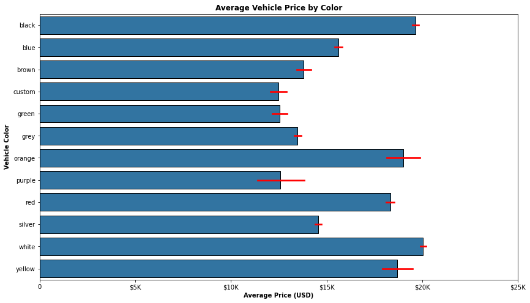

```python
# look at average vehicle price by color
plt.figure(figsize=[14, 8])
sns.barplot(data = cars_df_clean, x = 'price', y = 'paint_color', color = sns.color_palette()[0],
           order = color_vals.index, edgecolor = 'black', errcolor = 'Red')
plt.xticks([0, 5000, 10000, 15000, 20000, 25000],
          [0, '$5K', '$10K', '$15K', '$20K', '$25K'])
plt.ylabel('Vehicle Color', weight = 'bold')
plt.xlabel('Average Price (USD)', weight = 'bold')
plt.title('Average Vehicle Price by Color', weight = 'bold');
```

> Black and white vehicles have the highest average price. Purple and green, the lowest average price.

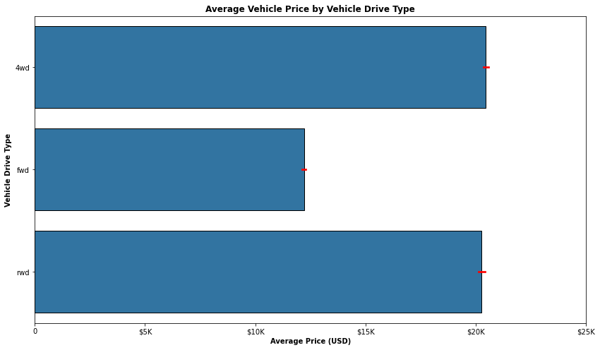

```python
# look at average vehicle price by drive type
plt.figure(figsize=[14, 8])
sns.barplot(data = cars_df_clean, x = 'price', y = 'drive', color = sns.color_palette()[0],
           order = drive_vals.index, edgecolor = 'black', errcolor = 'Red')
plt.xticks([0, 5000, 10000, 15000, 20000, 25000],
          [0, '$5K', '$10K', '$15K', '$20K', '$25K'])
plt.ylabel('Vehicle Drive Type', weight = 'bold')
plt.xlabel('Average Price (USD)', weight = 'bold')
plt.title('Average Vehicle Price by Vehicle Drive Type', weight = 'bold');
```

> Four-wheel drive and rear-wheel drive are both north of 20K average price.

### Categorical v. Categorical

#### What is the distribution of manufacturer across vehicle condition?

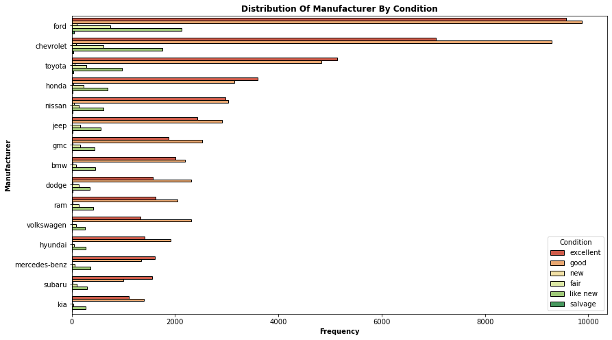

```python
# Manufacturer frequency across vehicle condition
subCountPlot(cars_df_clean, plt_var = 'manufacturer', hue_var = 'condition',
             palette = 'RdYlGn', order = manuf_vals.index, xy = 'y')
plt.legend(title = 'Condition');
```

> Ford and Chevy vehicles are most frequent across vehicle condition and well ahead with vehicles in good or excellent condition.

#### What is the distribution of vehicle model across vehicle condition?

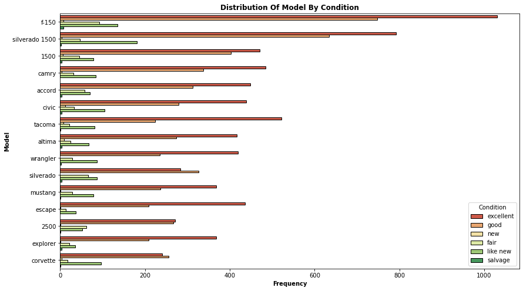

```python
# Vehicle model frequency across vehicle condition
subCountPlot(cars_df_clean, plt_var = 'model', hue_var = 'condition',
             palette = 'RdYlGn', order = model_vals.index, xy = 'y')
plt.legend(title = 'Condition');
```

> Given the manufacturer results, it makes sense that the Ford F-150 and Chevy Silverade occur most frequently across vehicle condition and - again - are clearly out front with vehicles in good or excellent condition.

#### What is the distribution of vehicle type across vehicle condition?

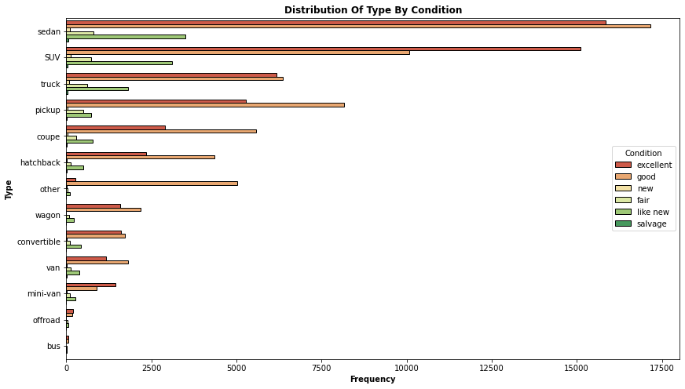

```python
# Vehicle type frequency across vehicle condition
subCountPlot(cars_df_clean, plt_var = 'type', hue_var = 'condition',
             palette = 'RdYlGn', order = type_vals.index, xy = 'y')
plt.legend(title = 'Condition');
```

> Sedans and SUVs occur most frequently across vehicle condition and are well out front with vehicles in good or excellent condition.

#### What is the distribution of vehicle model across vehicle drive type?

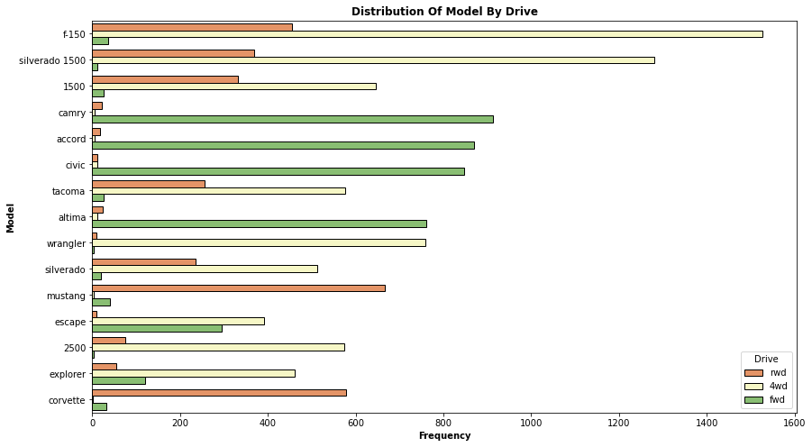

```python
# Model frequency across vehicle drive type
subCountPlot(cars_df_clean, plt_var = 'model', hue_var = 'drive',
             palette = 'RdYlGn', order = model_vals.index, xy = 'y')
plt.legend(title = 'Drive');
```

> It makes sense that four-wheel drive is the most frequent for various truck and SUV models. Toyota Camry and Honda Accord occur most frequently for the front-wheel drive category.

#### What is the distribution of vehicle type across vehicle drive type?

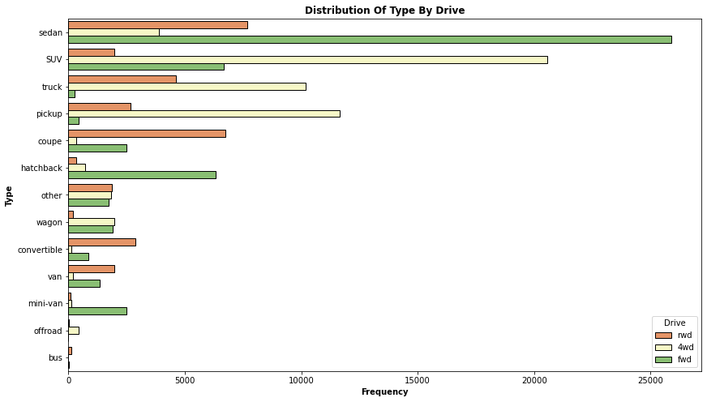

```python
# Vehicle type frequency across vehicle drive type
subCountPlot(cars_df_clean, plt_var = 'type', hue_var = 'drive',
             palette = 'RdYlGn', order = type_vals.index, xy = 'y')
plt.legend(title = 'Drive');
```

> Sedans are well out front in front- and rear-wheel drive. Trucks and SUVs are most frequent in four-wheel drive.

### Multivariate Exploration

#### What is the average vehicle price by manufacturer across condition?

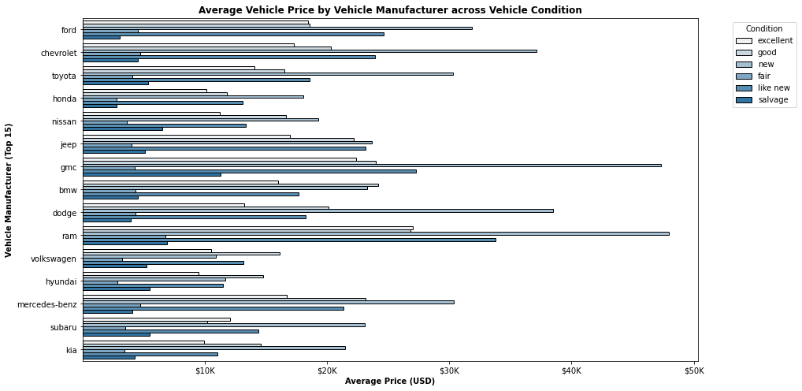

```python
# look at average vehicle price by state
plt.figure(figsize=[14, 8])
sns.barplot(data = cars_df_clean, x = 'price', y = 'manufacturer', hue = 'condition',
            color = sns.color_palette()[0], ci = None, order = manuf_vals.index,
            edgecolor = 'black')
plt.xticks([10000, 20000, 30000, 40000, 50000],
          ['$10K', '$20K', '$30K', '$40K', '$50K'])
plt.xlabel('Average Price (USD)', weight = 'bold')
plt.ylabel('Vehicle Manufacturer (Top 15)', weight = 'bold')
plt.title('Average Vehicle Price by Vehicle Manufacturer across Vehicle Condition', weight = 'bold')
plt.legend(title = 'Condition', bbox_to_anchor=(1.05, 1.0), loc='upper left');
```

> Ram and GMC vehicles in **new** condition have the highest average prices

#### What is the distribution of vehicle price by vehicle type across condition?

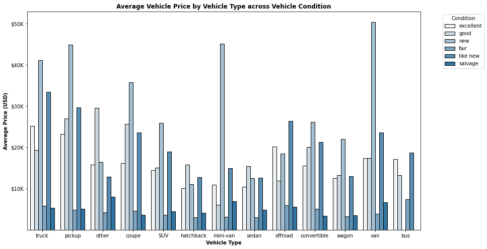

```python
# look at average vehicle price by vehicle type
plt.figure(figsize=[14, 8])
sns.barplot(data = cars_df_clean, y = 'price', x = 'type', hue = 'condition',
            color = sns.color_palette()[0], ci = None, edgecolor = 'black', errcolor = 'Red')
plt.yticks([10000, 20000, 30000, 40000, 50000],
          ['$10K', '$20K', '$30K', '$40K', '$50K'])
plt.xlabel('Vehicle Type', weight = 'bold')
plt.ylabel('Average Price (USD)', weight = 'bold')
plt.title('Average Vehicle Price by Vehicle Type across Vehicle Condition', weight = 'bold')
plt.legend(title = 'Condition', bbox_to_anchor=(1.05, 1.0), loc='upper left');
```

#### What is the distribution of vehicle age by manufacturer across vehicle condition?

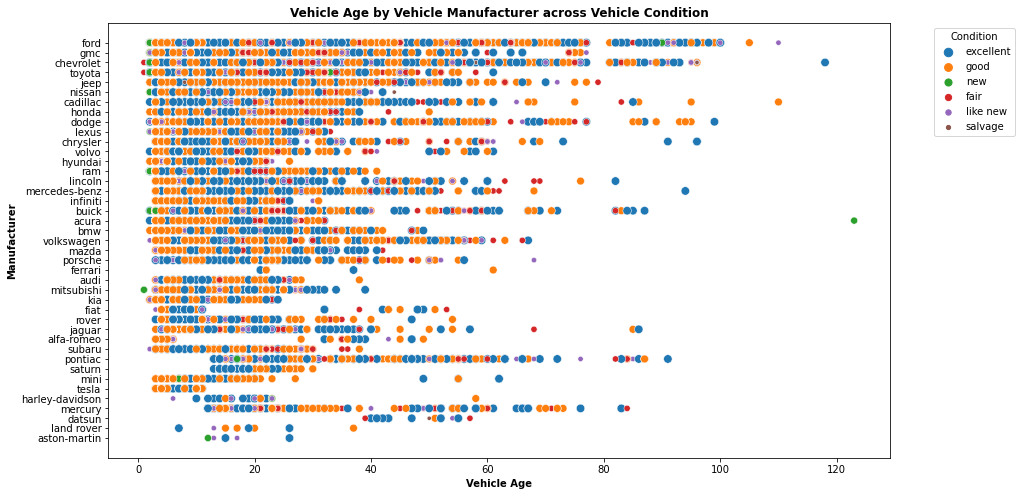

```python
plt.figure(figsize=[14, 8])
sns.scatterplot(data = cars_df_clean, x = 'vehicle_age', y = 'manufacturer', hue = 'condition',
               size = 'condition')
plt.xlabel('Vehicle Age', weight = 'bold')
plt.ylabel('Manufacturer', weight = 'bold')
plt.title('Vehicle Age by Vehicle Manufacturer across Vehicle Condition', weight = 'bold')
plt.legend(title = 'Condition', bbox_to_anchor=(1.05, 1.0), loc='upper left');
```

> It makes sense to see that vehicles in good or excellent condition across manufacturer and age.

#### What is the distribution of vehicle age by vehicle type across vehicle condition?

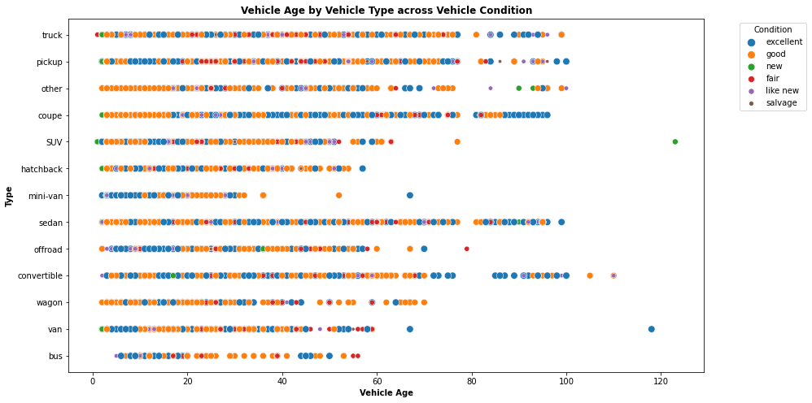

```python
plt.figure(figsize=[14, 8])
sns.scatterplot(data = cars_df_clean, x = 'vehicle_age', y = 'type', hue = 'condition',
               size = 'condition')
plt.xlabel('Vehicle Age', weight = 'bold')
plt.ylabel('Type', weight = 'bold')
plt.title('Vehicle Age by Vehicle Type across Vehicle Condition', weight = 'bold')
plt.legend(title = 'Condition', bbox_to_anchor=(1.05, 1.0), loc='upper left');
```

> Vehicles in good or excellent condition age well regardless of vehicle type.

#### What is the distribution of avergae vehicle price by manufacturer across drive type?

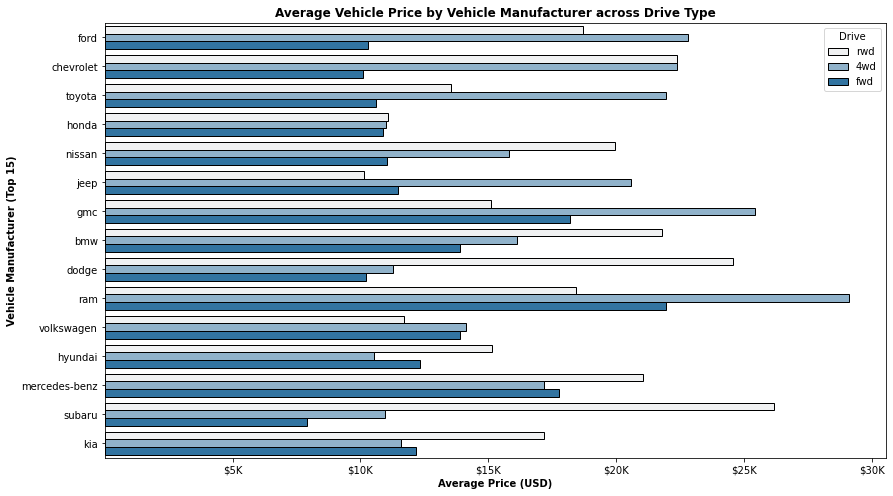

```python
# look at average vehicle price by state
plt.figure(figsize=[14, 8])
sns.barplot(data = cars_df_clean, x = 'price', y = 'manufacturer', hue = 'drive',
            color = sns.color_palette()[0], ci = None, order = manuf_vals.index,
            edgecolor = 'black')
plt.xticks([5000, 10000, 15000, 20000, 25000, 30000],
          ['$5K', '$10K', '$15K', '$20K', '$25K', '$30K'])
plt.xlabel('Average Price (USD)', weight = 'bold')
plt.ylabel('Vehicle Manufacturer (Top 15)', weight = 'bold')
plt.title('Average Vehicle Price by Vehicle Manufacturer across Drive Type', weight = 'bold')
plt.legend(title = 'Drive');
```

> In many cases, four-wheel drive vehicles have the highest average price

#### What is the distribution of average price by vehicle type across drive type?

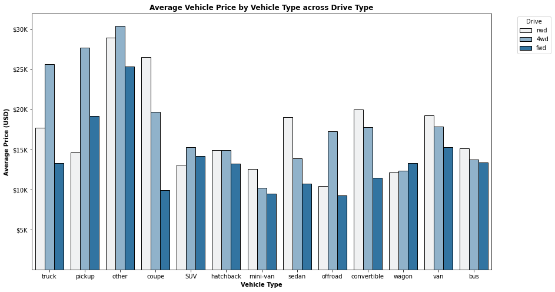

```python
# look at average vehicle price by vehicle type
plt.figure(figsize=[14, 8])
sns.barplot(data = cars_df_clean, y = 'price', x = 'type', hue = 'drive',
            color = sns.color_palette()[0], ci = None, edgecolor = 'black')
plt.yticks([5000, 10000, 15000, 20000, 25000, 30000],
          ['$5K', '$10K', '$15K', '$20K', '$25K', '$30K'])
plt.xlabel('Vehicle Type', weight = 'bold')
plt.ylabel('Average Price (USD)', weight = 'bold')
plt.title('Average Vehicle Price by Vehicle Type across Drive Type', weight = 'bold')
plt.legend(bbox_to_anchor=(1.05, 1.0), loc='upper left', title = 'Drive');
```